# Emily’s Visual Data Story

What Can We Learn from Study Breaks?

Emily - Back from Welly edition 💨

2026-05-11

## Welcome

[figure not shown]

**A Word from the Author**

We are all, at one fleeting chapter of our existence, *students*. Weary scholars stationed at tiny desks beneath unforgiving fluorescent lights, clutching half-finished notes and lukewarm beverages 🪔. And surely, at some desperate hour, we have all surrendered to the sacred ritual known as the **study break**.

📩 I invite you now into a world of peculiar wonders and quiet magic. A world where study breaks drift elegantly across the *days of the week,* where certain afternoons demand *longer pauses than others*, and where the most *extravagant breaks possess reasons as fascinating as the breaks themselves*. Through the data gathered from our survey form, we uncovered patterns both charming and revealing.

So, dear reader, prepare to be amazed.

### I present to you: the great Budapest Hotel of study breaks.What’s going on with this data? 💫

## The Weekly Waltz of Academic Escape

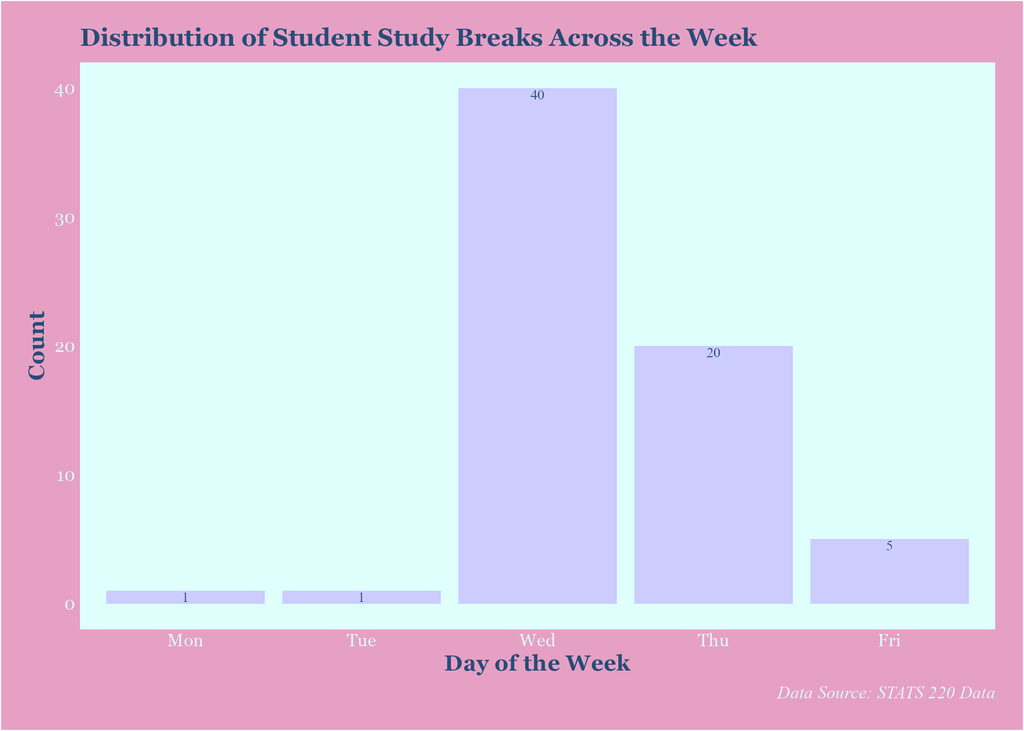

Bar chart titled “Distribution of Student Study Breaks Across the Week.” Wednesday had the highest number of study breaks, with 40 out of 67 observations.

Like a Waltz, students elegantly dance around tasks with which they share a curious love-hate relationship. 💃🏻

This bar chart serves as a perfect illustration of that phenomenon. Across the working week, the greatest number of study breaks were taken on Wednesday, accounting for 40 out of 67 observations (60%).

Is it merely a coincidence that this also happens to be the day when Stats 220 projects are due, thus inspiring a heightened sense of academic anxiety? We may never know. What does seem logical, however, is that students required more breaks in the middle of the week, with Thursday following behind (30%), because it sits in that peculiar position of being tantalisingly close to the weekend, yet still frustratingly far away.

## The Lengthening Intermissions of the Academic Week

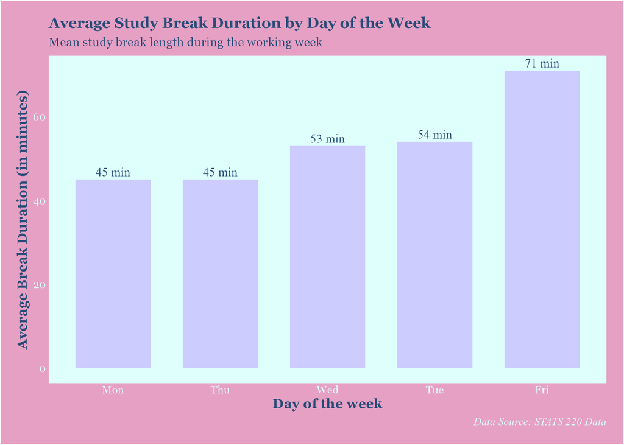

Bar chart titled “Average Study Break Duration by Day of the Week.” Most study break durations tend to be similar from Monday to Thursday, ranging from around 45 to 54 minutes, with Friday peaking at 71 minutes.

So, how long was the intermission?

Well, the average study break duration remained mostly consistent from Monday to Thursday, ranging from around 45 to 54 minutes. The amount of studying completed before the break was taken is something we do not know. However, this bar chart reveals that on Fridays, people tended to require a considerably longer break, averaging around 71 minutes (more than an hour).

The numbers speak for themselves. When one must continue grinding while being so close to the finish line, a longer study break becomes necessary to keep the motivation alive.

[figure not shown]

Scene from the Grand Budapest Hotel depicting how fast the students run towards a study break

## Where Time Went, and Why

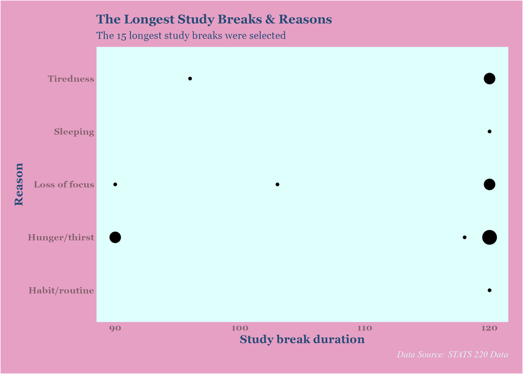

I will not be able to provide a philosophical answer. However, I can try my best to provide a statistical interpretation based on the plot I have created.

This dot plot presents the 15 longest study breaks from the data collected, with the longest being 2 hours (the maximum allowed by the Google Form). The size of each dot represents the frequency of each reason.

The most frequent reason for the longest break of 120 minutes is hunger/thirst, followed by tiredness and loss of focus. Hunger/thirst also appears as a common reason for shorter long breaks at around 90 minutes.

Overall, it is encouraging to see that students are taking care of themselves by taking breaks when they need to refuel.

## The End

[figure not shown]

A hug from the movie because you always need to take care of yourself